# Taxonomy harmonization QC report

21-Jul-2026

RepDBmaker harmonizes the UniProt (NCBI) and P10K (native) eukaryotic taxonomies into the UniEuk/EukProt framework.

```r
suppressPackageStartupMessages(library(tidyverse))
suppressPackageStartupMessages(library(ape))
suppressPackageStartupMessages(library(ggtree))
suppressPackageStartupMessages(library(ggtreeExtra))
theme_set(theme_classic())

# shared helpers (RANKS, rp, read_prefixed, changed, ambiguous_mnemos,
# modal_parent) and palettes (color_dbs); source them whether the working
# directory is the repo root or workflow/notebooks/
.src <- function(p) source(if (file.exists(p)) p else file.path("..", "..", p))
.src("workflow/scripts/functions.R")
.src("workflow/scripts/palettes.R")

# resolve inputs/outdir from the snakemake object (pipeline, script: directive)
# or the YAML params (standalone rendering); `params` itself is locked.
P <- if (exists("snakemake")) {
  list(
    eukprot        = snakemake@input[["eukprot"]],
    uniprot_ncbi   = snakemake@input[["uniprot_ncbi"]],
    uniprot_unieuk = snakemake@input[["uniprot_unieuk"]],
    p10k_orig      = snakemake@input[["p10k_orig"]],
    p10k_unieuk    = snakemake@input[["p10k_unieuk"]],
    custom         = snakemake@input[["custom"]],
    outdir         = dirname(snakemake@output[["html"]])
  )
} else {
    list(
    eukprot        = "results/taxonomies/eukprot_taxonomy.tsv",
    uniprot_ncbi   = "results/taxonomies/uniprot_ncbi_taxonomy.tsv",
    uniprot_unieuk = "results/taxonomies/uniprot_eukprot_taxonomy.tsv",
    p10k_orig      = "results/meta/p10k_lineage.tsv",
    p10k_unieuk    = "results/taxonomies/p10k_taxonomy.tsv",
    custom         = "results/taxonomies/custom_taxonomy.tsv",
    outdir         = "results/qc/"
  )
}

outdir <- rp(P$outdir)
dir.create(outdir, showWarnings = FALSE, recursive = TRUE)
```

# Eukaryotic taxonomic backbone tree

The tree is the taxonomic backbone (`domain/phylum/class/order/family`) with EukProt as the scaffold. **Branches are coloured by database origin**. The outer **stacked bar plot** gives the number of proteomes per family contributed by each database (scaled with squared root).

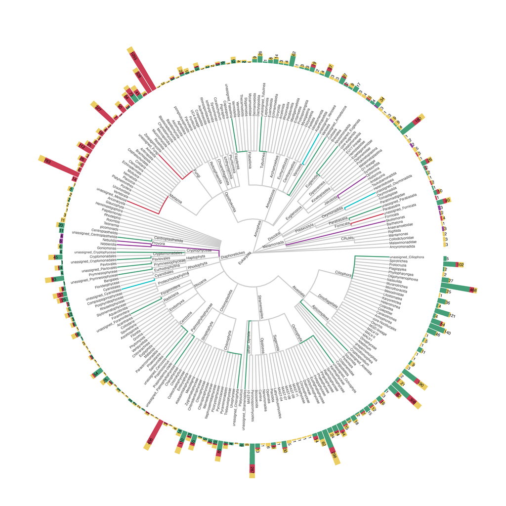

```r
bb_ranks <- c("d", "p", "c", "o", "f")

# harmonized taxonomies of the eukaryotic sources, tagged by source; custom optional
srcs <- list(
  read_prefixed(P$eukprot) %>% mutate(source = "eukprot"),
  read_prefixed(P$uniprot_unieuk) %>% mutate(source = "uniprot"),
  read_prefixed(P$p10k_unieuk) %>% mutate(source = "p10k")
)
custom_path <- rp(P$custom)
if (!is.null(P$custom) && file.exists(custom_path) &&
  nrow(read_tsv(custom_path, col_names = FALSE, col_types = cols(), n_max = 1)) > 0) {
  srcs <- c(srcs, list(read_prefixed(custom_path) %>% mutate(source = "custom")))
}
all_tax <- bind_rows(srcs) %>%
  filter(if_all(all_of(bb_ranks), ~ !is.na(.) & . != ""))

# Resolve a single consistent parent per node (top-down, by frequency) so the
# union of the sources is a valid tree even where they disagree (modal_parent
# lives in workflow/scripts/functions.R).
bb_tax <- modal_parent(all_tax, "f", "o") %>%
  left_join(modal_parent(all_tax, "o", "c"), by = "o") %>%
  left_join(modal_parent(all_tax, "c", "p"), by = "c") %>%
  left_join(modal_parent(all_tax, "p", "d"), by = "p") %>%
  distinct(d, p, c, o, f) %>%
  mutate(across(everything(), factor))
backbone_tree <- as.phylo(~ d / p / c / o / f, data = bb_tax, collapse = TRUE)

# origin of each clade (any rank): grey if in EukProt, else the db(s) that add it
clade_origin <- all_tax %>%
  select(source, all_of(c("p", "c", "o", "f"))) %>%
  pivot_longer(-source, values_to = "clade") %>%
  filter(clade != "" & !is.na(clade)) %>%
  distinct(clade, source) %>%
  group_by(clade) %>%
  summarise(origin = if ("eukprot" %in% source) {
    "EukProt (backbone)"
  } else {
    paste(sort(unique(source)), collapse = "+")
  }, .groups = "drop")

# per-family proteome counts by db (for the stacked-bar ring)
db_lv <- intersect(c("eukprot", "uniprot", "p10k", "custom"), unique(all_tax$source))
fam_long <- all_tax %>%
  distinct(mnemo, f, source) %>%
  count(f, source, name = "n") %>%
  mutate(source = factor(source, levels = db_lv))

# branch palette: grey backbone, canonical db colours, hue for combos
td <- fortify(backbone_tree) %>%
  left_join(clade_origin, by = c("label" = "clade")) %>%
  mutate(origin = replace_na(origin, "EukProt (backbone)"))
added_lv <- sort(setdiff(unique(td$origin), "EukProt (backbone)"))
origin_pal <- setNames(scales::hue_pal()(max(length(added_lv), 1))[seq_along(added_lv)], added_lv)
for (s in names(color_dbs)) if (s %in% added_lv) origin_pal[s] <- color_dbs[[s]]
origin_pal["EukProt (backbone)"] <- "grey80"

p <- ggtree(td, layout = "circular",
            aes(colour = origin), linewidth = 0.4) +
  scale_colour_manual(values = origin_pal, name = "branch origin") +
  geom_tiplab(size = 1, colour = "grey20",
              offset = 0, hjust = 0) +
  geom_fruit_list(
  geom_fruit(
    data = fam_long, geom = geom_col,
    mapping = aes(y = f, x = sqrt(n), fill = source),
    orientation = "y", pwidth = 0.4, offset = .4
  ),
  geom_fruit(
    data = group_by(fam_long, f) %>%
      summarise(n=sum(n)),
    geom = geom_text,
    mapping = aes(y = f, label = n, x=sqrt(n)),
    orientation = "y",
    hjust = 0, size = 1.2, offset = .4, pwidth = 0.4
  )) +
  # labs(subtitle = "EukProt taxonomic tree with log-scaled # of proteomes by DB") +
  geom_nodelab(size = 1.1, colour = "grey20",
               hjust = 1.1, vjust=-0.5) +
  scale_fill_manual(values = color_dbs, name = "proteomes (db)") +
  theme(legend.position = "none",
        plot.margin       = margin(t = -40, r = -40,
                                   b = -40, l = -40, unit = "pt") )

p
```

# UniProt: NCBI → UniEuk

```r
ncbi <- read_prefixed(P$uniprot_ncbi)
uni <- read_prefixed(P$uniprot_unieuk)
up_ambig <- ambiguous_mnemos(uni)
cmp <- c("p", "c", "o", "f", "g", "s") # domain empty in NCBI, skip

up <- uni %>%
  select(mnemo, unieuk_lineage = lineage, all_of(cmp)) %>%
  rename_with(~ paste0(.x, "_unieuk"), all_of(cmp)) %>%
  left_join(ncbi %>% select(mnemo, ncbi_lineage = lineage, all_of(cmp)) %>%
    rename_with(~ paste0(.x, "_ncbi"), all_of(cmp)), by = "mnemo") %>%
  mutate(ambiguous = mnemo %in% up_ambig)

for (r in cmp) {
  up[[paste0(r, "_changed")]] <- changed(
    up[[paste0(r, "_ncbi")]],
    up[[paste0(r, "_unieuk")]]
  )
}
chg <- as.matrix(up[paste0(cmp, "_changed")])
up$n_ranks_changed <- rowSums(chg)
up$changed_ranks <- apply(chg, 1, function(x) paste(cmp[x], collapse = ","))
up_detail <- up %>% select(
  mnemo, ambiguous, n_ranks_changed, changed_ranks,
  ncbi_lineage, unieuk_lineage, ends_with("_ncbi"), ends_with("_unieuk")
)
up_cross <- up %>%
  count(ncbi_phylum = p_ncbi, unieuk_phylum = p_unieuk, name = "n") %>%
  arrange(desc(n))
```

There are 3528 UniProt proteomes; **0** are *ambiguous* (mapped to more than one UniEuk lineage). Because NCBI and UniEuk use “phylum” for different concepts, most phylum labels are re-assigned.

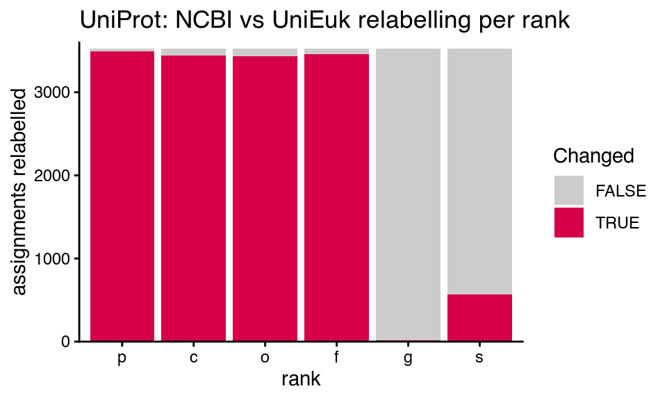

```r
up %>%
  select(paste0(cmp, "_changed")) %>%
  pivot_longer(cols = everything()) %>%
  mutate(rank = factor(gsub("_changed", "", name), levels = cmp)) %>%
  ggplot(aes(rank, fill = value)) +
  geom_bar() +
  labs(
    x = "rank", y = "assignments relabelled",
    fill = "Changed",
    title = "UniProt: NCBI vs UniEuk relabelling per rank"
  ) +
  scale_fill_manual(values = c("grey80", "#D50048")) +
  scale_y_continuous(expand = expansion(c(0, 0.02)))
```

These are the cross-translation from NCBI phyla to UniEuk phyla. As UniProt is very rich in opisthokonta most of these groups end up in the phylum Amorphea.

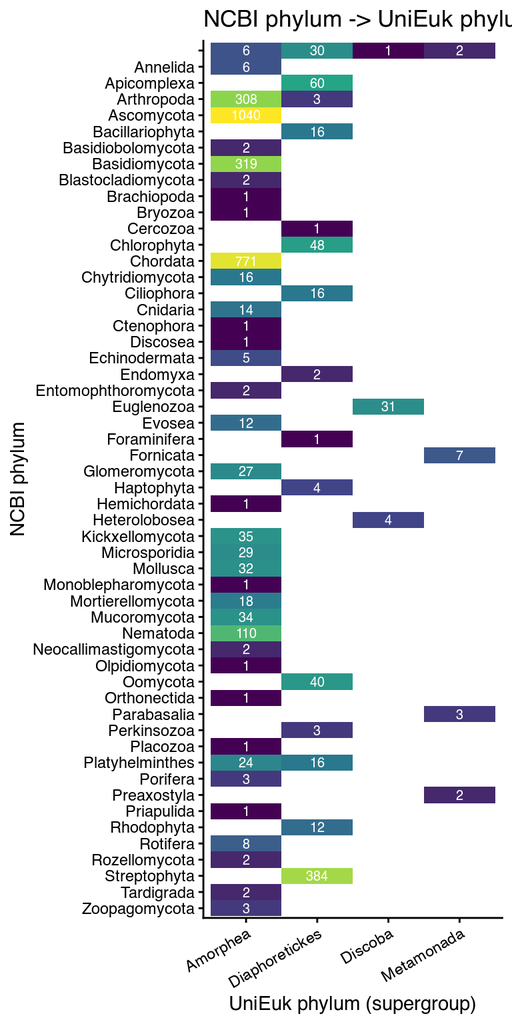

```r
up_cross %>%
  # filter(ncbi_phylum %in% top_phyla, ncbi_phylum != "", unieuk_phylum != "") %>%
  ggplot(aes(unieuk_phylum, fct_rev(ncbi_phylum), fill = n)) +
  geom_tile() +
  geom_text(aes(label = n), size = 2.6, colour = "white") +
  scale_fill_viridis_c(trans = "log10") +
  labs(
    x = "UniEuk phylum (supergroup)", y = "NCBI phylum",
    title = "NCBI phylum -> UniEuk phylum"
  ) +
  theme(axis.text.x = element_text(angle = 30, hjust = 1),
        legend.position = "none")
```

```r
if (length(up_ambig) > 0) {
  uni %>%
    filter(mnemo %in% up_ambig) %>%
    select(mnemo, lineage) %>%
    arrange(mnemo) %>%
    head(10) %>%
    knitr::kable(caption = "Examples of ambiguous UniProt proteomes (first 10)")
}
```

# P10K: native → UniEuk

```r
p10k_cols <- c(
  "supergroup", "phylum", "class",
  "order", "family", "genus", "sp"
)
p10k_orig <- read_tsv(rp(P$p10k_orig),
  col_names = c("mnemo", "species", "lineage"),
  col_types = cols(.default = "c"),
  name_repair = "minimal"
) %>%
  distinct() %>%
  separate(lineage, p10k_cols, sep = ";", fill = "right", extra = "drop", remove = FALSE) %>%
  rename(orig_lineage = lineage) %>%
  mutate(
    supergroup = trimws(supergroup),
    across(all_of(p10k_cols[-1]), ~ trimws(gsub("^[A-Z]_", "", .)))
  )
p10k_harm <- read_prefixed(P$p10k_unieuk) %>% rename(unieuk_lineage = lineage)
p10_ambig <- ambiguous_mnemos(p10k_harm %>% rename(lineage = unieuk_lineage))
p10 <- p10k_harm %>%
  left_join(p10k_orig %>% select(mnemo, orig_lineage, supergroup, orig_genus = genus), by = "mnemo") %>%
  mutate(genus_changed = changed(orig_genus, g), ambiguous = mnemo %in% p10_ambig)
p10_detail <- p10 %>% transmute(mnemo, ambiguous,
  orig_supergroup = supergroup,
  unieuk_phylum = p, unieuk_class = c, orig_genus, unieuk_genus = g,
  genus_changed, orig_lineage, unieuk_lineage
)
p10_cross <- p10 %>%
  count(p10k_supergroup = supergroup, unieuk_phylum = p, name = "n") %>%
  arrange(desc(n))
```

There are 2956 P10K proteomes; **0** ambiguous, **47** with a changed genus. P10K’s native NCBI-based supergroups are translated to UniEuk phyla as follows:

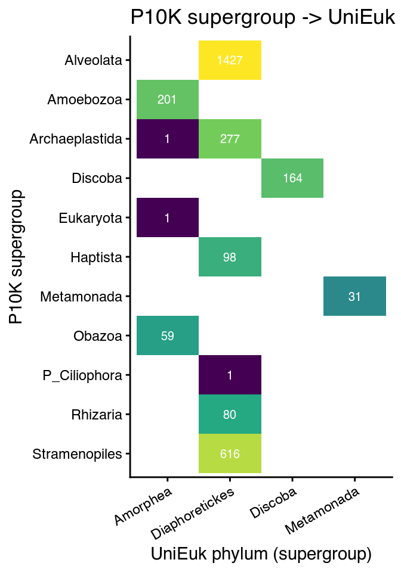

```r
p10_cross %>%
  filter(p10k_supergroup != "", unieuk_phylum != "") %>%
  ggplot(aes(unieuk_phylum, fct_rev(p10k_supergroup), fill = n)) +
  geom_tile() +
  geom_text(aes(label = n), size = 2.6, colour = "white") +
  scale_fill_viridis_c(trans = "log10") +
  labs(
    x = "UniEuk phylum (supergroup)", y = "P10K supergroup",
    title = "P10K supergroup -> UniEuk phylum"
  ) +
  theme(axis.text.x = element_text(angle = 30, hjust = 1),
        legend.position = "none")
```

Here you can see those with changed genuses, most of them should be from unassigned species/genuses.

```r
p10 %>%
  filter(genus_changed) %>%
  select(mnemo, unieuk_lineage, orig_lineage) %>%
  knitr::kable(caption = "P10k Changed genuses")
```

P10k Changed genuses

| mnemo | unieuk_lineage | orig_lineage |
| --- | --- | --- |
| P10K-MW-000007 | d__Eukaryota;p__Diaphoretickes;c__Alveolata;o__Ciliophora;f__Oligohymenophorea;g__Uronema;s__Uronema sp. SZ | Alveolata;P_Ciliophora;C_Oligohymenophorea;O_Scuticociliatia;F_Philasterida;G_Uronematidae;S_ |
| P10K-MW-002960 | d__Eukaryota;p__Diaphoretickes;c__Alveolata;o__Ciliophora;f__Spirotrichea;g__Euplotes;s__Euplotes octocarinatus | P_Ciliophora;C_Spirotrichea;O_Euplotida;F_Euplotidae;G_Euplotes;S_Euplotes octocarinatus |
| P10K-NCBI-001521 | d__Eukaryota;p__Diaphoretickes;c__Alveolata;o__Ciliophora;f__Spirotrichea;g__Euplotes aediculatus;s__Euplotes aediculatus QDEA | Alveolata;P_Ciliophora;C_Spirotrichea;O_Euplotida;F_Euplotidae;G_Euplotes;S_Euplotes aediculatus QDEA |
| P10K-NCBI-001467 | d__Eukaryota;p__Diaphoretickes;c__Alveolata;o__Apicomplexa;f__coccidiomorphea;g__Haemoproteus;s__Haemoproteus tartakovskyi SISKIN1 | Alveolata;P_Apicomplexa;C_Aconoidasida;O_Haemosporida;F_Haemoproteidae;G_Parahaemoproteus;S_Haemoproteus tartakovskyi SISKIN1 |
| P10K-NCBI-002399 | d__Eukaryota;p__Diaphoretickes;c__Alveolata;o__unassigned_Alveolata;f__unassigned_Alveolata;g__Chromerida;s__Chromerida sp. RM11 | Alveolata;P_Alveolata_X;C_Alveolata_XX;O_Alveolata_XXX;F_Alveolata_XXXX;G_Alveolata_XXXXX;S_Chromerida sp. RM11 |
| P10K-NCBI-002786 | d__Eukaryota;p__Diaphoretickes;c__Alveolata;o__Ciliophora;f__unassigned_Ciliophora;g__uncultured;s__uncultured ciliate | Alveolata;P_Ciliophora;C_Ciliophora_X;O_Ciliophora_XX;F_Ciliophora_XXX;G_Ciliophora_XXXX;S_uncultured ciliate |
| P10K-NCBI-002795 | d__Eukaryota;p__Diaphoretickes;c__Chloroplastida;o__Chlorophyta;f__Mamiellophyceae;g__Mamiellaceae;s__Mamiellaceae sp. RCC2288 | Archaeplastida;P_Chlorophyta;C_Mamiellophyceae;O_Mamiellophyceae_X;F_Mamiellophyceae_XX;G_Mamiellophyceae_XXX;S_Mamiellaceae sp. RCC2288 |
| P10K-NCBI-001713 | d__Eukaryota;p__Diaphoretickes;c__Chloroplastida;o__Chlorophyta;f__Trebouxiophyceae;g__Trebouxiophyceae;s__Trebouxiophyceae sp. KSI-1 | Archaeplastida;P_Chlorophyta;C_Trebouxiophyceae;O_Trebouxiophyceae_X;F_Trebouxiophyceae_XX;G_Trebouxiophyceae_XXX;S_Trebouxiophyceae sp. KSI-1 |
| P10K-NCBI-002781 | d__Eukaryota;p__Diaphoretickes;c__Chloroplastida;o__Chlorophyta;f__unassigned_Chlorophyta;g__prasinophyte;s__prasinophyte sp. RCC997 | Archaeplastida;P_Chlorophyta;C_Chlorophyta_X;O_Chlorophyta_XX;F_Chlorophyta_XXX;G_Chlorophyta_XXXX;S_prasinophyte sp. RCC997 |
| P10K-NCBI-002782 | d__Eukaryota;p__Diaphoretickes;c__Chloroplastida;o__Chlorophyta;f__unassigned_Chlorophyta;g__prasinophyte;s__prasinophyte sp. RCC997 | Archaeplastida;P_Chlorophyta;C_Chlorophyta_X;O_Chlorophyta_XX;F_Chlorophyta_XXX;G_Chlorophyta_XXXX;S_prasinophyte sp. RCC997 |
| P10K-NCBI-002783 | d__Eukaryota;p__Diaphoretickes;c__Chloroplastida;o__Chlorophyta;f__unassigned_Chlorophyta;g__prasinophyte;s__prasinophyte sp. RCC997 | Archaeplastida;P_Chlorophyta;C_Chlorophyta_X;O_Chlorophyta_XX;F_Chlorophyta_XXX;G_Chlorophyta_XXXX;S_prasinophyte sp. RCC997 |
| P10K-NCBI-002784 | d__Eukaryota;p__Diaphoretickes;c__Chloroplastida;o__Chlorophyta;f__unassigned_Chlorophyta;g__prasinophyte;s__prasinophyte sp. RCC997 | Archaeplastida;P_Chlorophyta;C_Chlorophyta_X;O_Chlorophyta_XX;F_Chlorophyta_XXX;G_Chlorophyta_XXXX;S_prasinophyte sp. RCC997 |
| P10K-NCBI-002015 | d__Eukaryota;p__Diaphoretickes;c__Chloroplastida;o__Palmophyllophyceae;f__unassigned_Palmophyllophyceae;g__Prasinococcaceae;s__Prasinococcaceae sp. CCMP 1430 | Archaeplastida;P_Chlorophyta;C_Palmophyllophyceae;O_Prasinococcales;F_Prasinococcaceae;G_Prasinococcaceae_X;S_Prasinococcaceae sp. CCMP 1430 |
| P10K-NCBI-002720 | d__Eukaryota;p__Diaphoretickes;c__Cryptophyceae;o__Cryptomonadales;f__Cryptomonadales;g__Geminigera;s__Geminigera | Archaeplastida;P_Cryptophyta;C_Cryptophyceae;O_Pyrenomonadales;F_Pyrenomonadales_X;G_Geminigeraceae;S_Geminigera |
| P10K-NCBI-002640 | d__Eukaryota;p__Diaphoretickes;c__Cryptophyceae;o__unassigned_Cryptophyceae;f__unassigned_Cryptophyceae;g__Cryptophyta;s__Cryptophyta sp. CCMP2293 | Archaeplastida;P_Cryptophyta;C_Cryptophyceae;O_Cryptophyceae_X;F_Cryptophyceae_XX;G_Cryptophyceae_XXX;S_Cryptophyta sp. CCMP2293 |
| P10K-NCBI-002641 | d__Eukaryota;p__Diaphoretickes;c__Cryptophyceae;o__unassigned_Cryptophyceae;f__unassigned_Cryptophyceae;g__Cryptophyta;s__Cryptophyta sp. CCMP2293 | Archaeplastida;P_Cryptophyta;C_Cryptophyceae;O_Cryptophyceae_X;F_Cryptophyceae_XX;G_Cryptophyceae_XXX;S_Cryptophyta sp. CCMP2293 |
| P10K-NCBI-002642 | d__Eukaryota;p__Diaphoretickes;c__Cryptophyceae;o__unassigned_Cryptophyceae;f__unassigned_Cryptophyceae;g__Cryptophyta;s__Cryptophyta sp. CCMP2293 | Archaeplastida;P_Cryptophyta;C_Cryptophyceae;O_Cryptophyceae_X;F_Cryptophyceae_XX;G_Cryptophyceae_XXX;S_Cryptophyta sp. CCMP2293 |
| P10K-NCBI-002643 | d__Eukaryota;p__Diaphoretickes;c__Cryptophyceae;o__unassigned_Cryptophyceae;f__unassigned_Cryptophyceae;g__Cryptophyta;s__Cryptophyta sp. CCMP2293 | Archaeplastida;P_Cryptophyta;C_Cryptophyceae;O_Cryptophyceae_X;F_Cryptophyceae_XX;G_Cryptophyceae_XXX;S_Cryptophyta sp. CCMP2293 |
| P10K-NCBI-002636 | d__Eukaryota;p__Diaphoretickes;c__Haptophyta;o__Pavlovales;f__unassigned_Pavlovales;g__Pavlovales;s__Pavlovales sp. CCMP2436 | Haptista;P_Haptophyta;C_Haptophyta_X;O_Pavlovales;F_Pavlovales_X;G_Pavlovales_XX;S_Pavlovales sp. CCMP2436 |
| P10K-NCBI-002637 | d__Eukaryota;p__Diaphoretickes;c__Haptophyta;o__Pavlovales;f__unassigned_Pavlovales;g__Pavlovales;s__Pavlovales sp. CCMP2436 | Haptista;P_Haptophyta;C_Haptophyta_X;O_Pavlovales;F_Pavlovales_X;G_Pavlovales_XX;S_Pavlovales sp. CCMP2436 |
| P10K-NCBI-002638 | d__Eukaryota;p__Diaphoretickes;c__Haptophyta;o__Pavlovales;f__unassigned_Pavlovales;g__Pavlovales;s__Pavlovales sp. CCMP2436 | Haptista;P_Haptophyta;C_Haptophyta_X;O_Pavlovales;F_Pavlovales_X;G_Pavlovales_XX;S_Pavlovales sp. CCMP2436 |
| P10K-NCBI-002639 | d__Eukaryota;p__Diaphoretickes;c__Haptophyta;o__Pavlovales;f__unassigned_Pavlovales;g__Pavlovales;s__Pavlovales sp. CCMP2436 | Haptista;P_Haptophyta;C_Haptophyta_X;O_Pavlovales;F_Pavlovales_X;G_Pavlovales_XX;S_Pavlovales sp. CCMP2436 |
| P10K-NCBI-002320 | d__Eukaryota;p__Diaphoretickes;c__Rhizaria;o__Cercozoa;f__Chlorarachnea;g__Chlorarachniophyceae;s__Chlorarachniophyceae sp. BC52 | Rhizaria;P_Cercozoa;C_Chlorarachniophyceae;O_Chlorarachniophyceae_X;F_Chlorarachniophyceae_XX;G_Chlorarachniophyceae_XXX;S_Chlorarachniophyceae sp. BC52 |
| P10K-NCBI-002295 | d__Eukaryota;p__Diaphoretickes;c__Rhizaria;o__Cercozoa;f__unassigned_Cercozoa;g__Cercozoa;s__Cercozoa sp. | Rhizaria;P_Cercozoa;C_Cercozoa_X;O_Cercozoa_XX;F_Cercozoa_XXX;G_Cercozoa_XXXX;S_Cercozoa sp. |
| P10K-NCBI-002296 | d__Eukaryota;p__Diaphoretickes;c__Rhizaria;o__Cercozoa;f__unassigned_Cercozoa;g__Cercozoa;s__Cercozoa sp. | Rhizaria;P_Cercozoa;C_Cercozoa_X;O_Cercozoa_XX;F_Cercozoa_XXX;G_Cercozoa_XXXX;S_Cercozoa sp. |
| P10K-NCBI-002322 | d__Eukaryota;p__Diaphoretickes;c__Stramenopiles;o__Opalozoa;f__Bicosoecida;g__Bicosoecida;s__Bicosoecida sp. | Stramenopiles;P_Stramenopiles_X;C_Bigyra;O_Bicosoecida;F_Bicosoecida_X;G_Bicosoecida_XX;S_Bicosoecida sp. |
| P10K-NCBI-002747 | d__Eukaryota;p__Diaphoretickes;c__Stramenopiles;o__Ochrophyta;f__Chrysophyceae;g__Ochromonadaceae;s__Ochromonadaceae sp. CCMP2298 | Stramenopiles;P_Ochrophyta;C_Synurophyceae;O_Ochromonadales;F_Ochromonadaceae;G_OchromonadaceaeX;S_Ochromonadaceae sp. CCMP2298 |
| P10K-NCBI-002748 | d__Eukaryota;p__Diaphoretickes;c__Stramenopiles;o__Ochrophyta;f__Chrysophyceae;g__Ochromonadaceae;s__Ochromonadaceae sp. CCMP2298 | Stramenopiles;P_Ochrophyta;C_Synurophyceae;O_Ochromonadales;F_Ochromonadaceae;G_OchromonadaceaeX;S_Ochromonadaceae sp. CCMP2298 |
| P10K-NCBI-002749 | d__Eukaryota;p__Diaphoretickes;c__Stramenopiles;o__Ochrophyta;f__Chrysophyceae;g__Ochromonadaceae;s__Ochromonadaceae sp. CCMP2298 | Stramenopiles;P_Ochrophyta;C_Synurophyceae;O_Ochromonadales;F_Ochromonadaceae;G_OchromonadaceaeX;S_Ochromonadaceae sp. CCMP2298 |
| P10K-NCBI-002750 | d__Eukaryota;p__Diaphoretickes;c__Stramenopiles;o__Ochrophyta;f__Chrysophyceae;g__Ochromonadaceae;s__Ochromonadaceae sp. CCMP2298 | Stramenopiles;P_Ochrophyta;C_Synurophyceae;O_Ochromonadales;F_Ochromonadaceae;G_OchromonadaceaeX;S_Ochromonadaceae sp. CCMP2298 |
| P10K-NCBI-002644 | d__Eukaryota;p__Diaphoretickes;c__Stramenopiles;o__Ochrophyta;f__Dictyochophyceae;g__Pedinellales;s__Pedinellales sp. CCMP2098 | Stramenopiles;P_Ochrophyta;C_Dictyochophyceae;O_Pedinellales;F_Pedinellales_X;G_Pedinellales_XX;S_Pedinellales sp. CCMP2098 |
| P10K-NCBI-002645 | d__Eukaryota;p__Diaphoretickes;c__Stramenopiles;o__Ochrophyta;f__Dictyochophyceae;g__Pedinellales;s__Pedinellales sp. CCMP2098 | Stramenopiles;P_Ochrophyta;C_Dictyochophyceae;O_Pedinellales;F_Pedinellales_X;G_Pedinellales_XX;S_Pedinellales sp. CCMP2098 |
| P10K-NCBI-002646 | d__Eukaryota;p__Diaphoretickes;c__Stramenopiles;o__Ochrophyta;f__Dictyochophyceae;g__Pedinellales;s__Pedinellales sp. CCMP2098 | Stramenopiles;P_Ochrophyta;C_Dictyochophyceae;O_Pedinellales;F_Pedinellales_X;G_Pedinellales_XX;S_Pedinellales sp. CCMP2098 |
| P10K-NCBI-002647 | d__Eukaryota;p__Diaphoretickes;c__Stramenopiles;o__Ochrophyta;f__Dictyochophyceae;g__Pedinellales;s__Pedinellales sp. CCMP2098 | Stramenopiles;P_Ochrophyta;C_Dictyochophyceae;O_Pedinellales;F_Pedinellales_X;G_Pedinellales_XX;S_Pedinellales sp. CCMP2098 |
| P10K-NCBI-002632 | d__Eukaryota;p__Diaphoretickes;c__Stramenopiles;o__Ochrophyta;f__Pelagophyceae;g__Pelagophyceae;s__Pelagophyceae sp. CCMP2097 | Stramenopiles;P_Ochrophyta;C_Pelagophyceae;O_Pelagophyceae_X;F_Pelagophyceae_XX;G_Pelagophyceae_XXX;S_Pelagophyceae sp. CCMP2097 |
| P10K-NCBI-002633 | d__Eukaryota;p__Diaphoretickes;c__Stramenopiles;o__Ochrophyta;f__Pelagophyceae;g__Pelagophyceae;s__Pelagophyceae sp. CCMP2097 | Stramenopiles;P_Ochrophyta;C_Pelagophyceae;O_Pelagophyceae_X;F_Pelagophyceae_XX;G_Pelagophyceae_XXX;S_Pelagophyceae sp. CCMP2097 |
| P10K-NCBI-002634 | d__Eukaryota;p__Diaphoretickes;c__Stramenopiles;o__Ochrophyta;f__Pelagophyceae;g__Pelagophyceae;s__Pelagophyceae sp. CCMP2097 | Stramenopiles;P_Ochrophyta;C_Pelagophyceae;O_Pelagophyceae_X;F_Pelagophyceae_XX;G_Pelagophyceae_XXX;S_Pelagophyceae sp. CCMP2097 |
| P10K-NCBI-002635 | d__Eukaryota;p__Diaphoretickes;c__Stramenopiles;o__Ochrophyta;f__Pelagophyceae;g__Pelagophyceae;s__Pelagophyceae sp. CCMP2097 | Stramenopiles;P_Ochrophyta;C_Pelagophyceae;O_Pelagophyceae_X;F_Pelagophyceae_XX;G_Pelagophyceae_XXX;S_Pelagophyceae sp. CCMP2097 |
| P10K-NCBI-002798 | d__Eukaryota;p__Diaphoretickes;c__Stramenopiles;o__Ochrophyta;f__Pelagophyceae;g__Pelagophyceae;s__Pelagophyceae sp. | Stramenopiles;P_Ochrophyta;C_Pelagophyceae;O_Pelagophyceae_X;F_Pelagophyceae_XX;G_Pelagophyceae_XXX;S_Pelagophyceae sp. |
| P10K-NCBI-002908 | d__Eukaryota;p__Diaphoretickes;c__Stramenopiles;o__Ochrophyta;f__Pelagophyceae;g__Pelagophyceae;s__Pelagophyceae sp. CCMP2135 | Stramenopiles;P_Ochrophyta;C_Pelagophyceae;O_Pelagophyceae_X;F_Pelagophyceae_XX;G_Pelagophyceae_XXX;S_Pelagophyceae sp. CCMP2135 |
| P10K-NCBI-002305 | d__Eukaryota;p__Diaphoretickes;c__Stramenopiles;o__unassigned_Stramenopiles;f__unassigned_Stramenopiles;g__labyrinthulid;s__labyrinthulid quahog parasite QPX | Stramenopiles;P_Stramenopiles_X;C_Bigyra;O_Bigyra_X;F_Bigyra_XX;G_Bigyra_XXX;S_labyrinthulid quahog parasite QPX |
| P10K-NCBI-002306 | d__Eukaryota;p__Diaphoretickes;c__Stramenopiles;o__unassigned_Stramenopiles;f__unassigned_Stramenopiles;g__labyrinthulid;s__labyrinthulid quahog parasite QPX | Stramenopiles;P_Stramenopiles_X;C_Bigyra;O_Bigyra_X;F_Bigyra_XX;G_Bigyra_XXX;S_labyrinthulid quahog parasite QPX |
| P10K-NCBI-002307 | d__Eukaryota;p__Diaphoretickes;c__Stramenopiles;o__unassigned_Stramenopiles;f__unassigned_Stramenopiles;g__labyrinthulid;s__labyrinthulid quahog parasite QPX | Stramenopiles;P_Stramenopiles_X;C_Bigyra;O_Bigyra_X;F_Bigyra_XX;G_Bigyra_XXX;S_labyrinthulid quahog parasite QPX |
| P10K-NCBI-002880 | d__Eukaryota;p__Diaphoretickes;c__Stramenopiles;o__unassigned_Stramenopiles;f__unassigned_Stramenopiles;g__labyrinthulid;s__labyrinthulid quahog parasite QPX | Stramenopiles;P_Stramenopiles_X;C_Bigyra;O_Bigyra_X;F_Bigyra_XX;G_Bigyra_XXX;S_labyrinthulid quahog parasite QPX |
| P10K-NCBI-001742 | d__Eukaryota;p__Discoba;c__Euglenozoa;o__Kinetoplastea;f__Metakinetoplastina;g__Trypanosomatidae;s__Trypanosomatidae sp. JR-2017a | Discoba;P_Euglenozoa;C_Kinetoplastea;O_Trypanosomatida;F_Trypanosomatidae;G_Trypanosomatidae_X;S_Trypanosomatidae sp. JR-2017a |
| P10K-NCBI-001743 | d__Eukaryota;p__Discoba;c__Euglenozoa;o__Kinetoplastea;f__Metakinetoplastina;g__Trypanosomatidae;s__Trypanosomatidae sp. JR-2017a | Discoba;P_Euglenozoa;C_Kinetoplastea;O_Trypanosomatida;F_Trypanosomatidae;G_Trypanosomatidae_X;S_Trypanosomatidae sp. JR-2017a |
| P10K-NCBI-002078 | d__Eukaryota;p__Discoba;c__Euglenozoa;o__Kinetoplastea;f__Metakinetoplastina;g__Trypanosomatidae;s__Trypanosomatidae sp. JR-2017a | Discoba;P_Euglenozoa;C_Kinetoplastea;O_Trypanosomatida;F_Trypanosomatidae;G_Trypanosomatidae_X;S_Trypanosomatidae sp. JR-2017a |

# Unassigned

Here you can see those species that have some missing data in their lineage. Most of them tend to be from P10K.

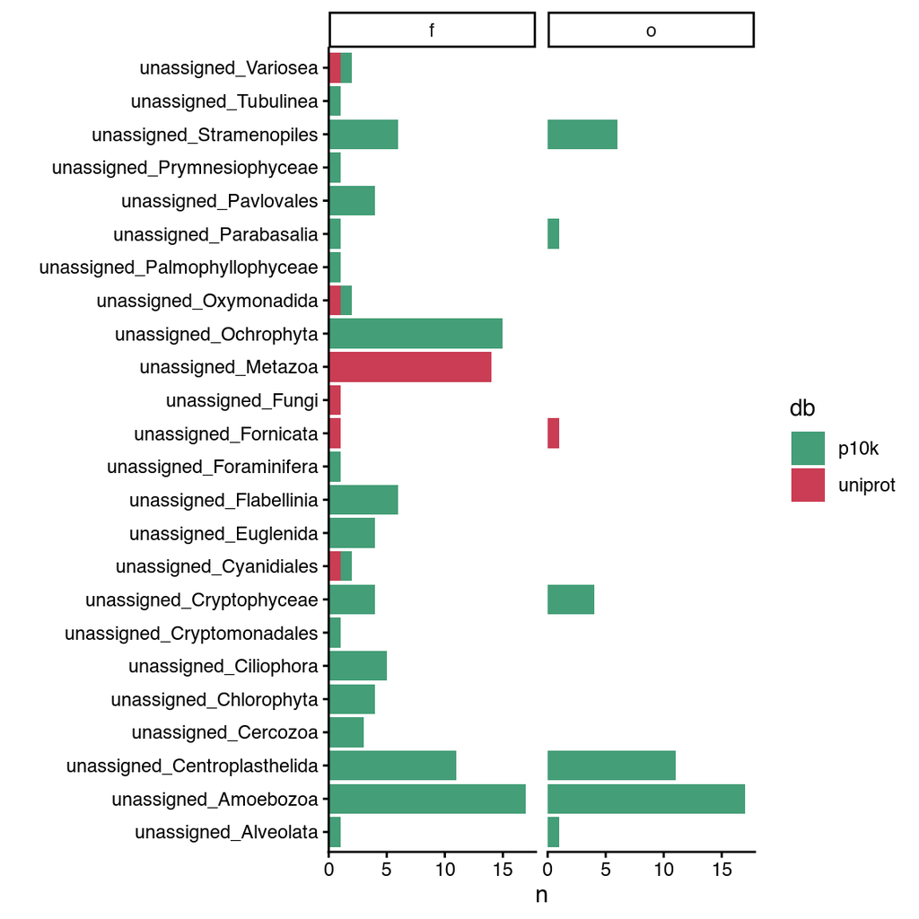

```r
all_tax %>%
  filter(grepl("unassigned", lineage)) %>%
  select(-lineage) %>%
  pivot_longer(cols = !c(mnemo, source)) %>%
  filter(grepl("unassigned", value)) %>%
  group_by(name, value, source) %>%
  count() %>%
  ggplot(aes(n, value, fill=source)) +
  geom_col(position="stack") +
  facet_grid(~name) +
  scale_x_continuous(expand = expansion(mult = c(0,0.05))) +
  scale_fill_manual(values = color_dbs) +
  labs(y="", fill="db")
```

# Summary and outputs

```r
summary <- tibble(
  metric = c(
    "uniprot_n_proteomes", "uniprot_n_harmonized_assignments",
    "uniprot_n_ambiguous", "uniprot_n_unharmonized", "uniprot_n_phylum_relabelled",
    "p10k_n_proteomes", "p10k_n_ambiguous", "p10k_n_unharmonized",
    "p10k_n_genus_changed", "p10k_n_unieuk_phylum_empty", "p10k_n_unieuk_class_empty"
  ),
  value = c(
    n_distinct(uni$mnemo), nrow(uni), length(up_ambig),
    sum(!ncbi$mnemo %in% uni$mnemo), n_distinct(up$mnemo[changed(up$p_ncbi, up$p_unieuk)]),
    n_distinct(p10k_harm$mnemo), length(p10_ambig), sum(!p10k_orig$mnemo %in% p10k_harm$mnemo),
    n_distinct(p10$mnemo[p10$genus_changed]), sum(p10$p == "" | is.na(p10$p)),
    sum(p10$c == "" | is.na(p10$c))
  )
)
knitr::kable(summary, caption = "Harmonization summary")
```

Harmonization summary

| metric | value |
| --- | --- |
| uniprot_n_proteomes | 3528 |
| uniprot_n_harmonized_assignments | 3528 |
| uniprot_n_ambiguous | 0 |
| uniprot_n_unharmonized | 0 |
| uniprot_n_phylum_relabelled | 3489 |
| p10k_n_proteomes | 2956 |
| p10k_n_ambiguous | 0 |
| p10k_n_unharmonized | 0 |
| p10k_n_genus_changed | 47 |
| p10k_n_unieuk_phylum_empty | 0 |
| p10k_n_unieuk_class_empty | 0 |

```r
ambiguous <- bind_rows(
  uni %>% filter(mnemo %in% up_ambig) %>% transmute(source = "uniprot", mnemo, unieuk_lineage = lineage),
  p10k_harm %>% filter(mnemo %in% p10_ambig) %>% transmute(source = "p10k", mnemo, unieuk_lineage)
) %>% arrange(source, mnemo)

# machine-readable outputs
write_tsv(up_detail, file.path(outdir, "harmonization_uniprot.tsv"))
write_tsv(p10_detail, file.path(outdir, "harmonization_p10k.tsv"))
write_tsv(ambiguous, file.path(outdir, "harmonization_ambiguous.tsv"))
```